# هوش مصنوعی

## پروژه صفرم - آشنایی با هوش مصنوعی

### محیا قینی -810196615

###### مهر1399

## هدف پروژه

در این پروژه می خواهیم آشنایی کلی و اولیه ای با هوش مصنوعی پیدا کنیم. در هوش مصنوعی در اکثر مسائل هدف پیش بینی یا دسته بندی است. در این پروژه یک شکل از مسئله پیش بینی را خواهیم دید. بنابراین در این پروژه تصمیم داریم در دیتاست داده شده با توجه به ویژگی ها، ستون هدف را در جایی که داده نشده است پیش بینی کنیم.

## صورت مسئله

ما اطلاعات 1000 کاربر یک سایت را در اختیار داریم، این اطلاعات شامل چند ویژگی و یک داده هدف است. حال ما می خواهیم با کمک الگوریتم های یادگیری ماشین راهی ایجاد کنیم تا داده هدف تا حد خوبی قابل پیش بینی باشد و برای تست آن در نهایت با ابزار پیش بینی که تولید کردیم سطر های خالی داده هدف را پر خواهیم کرد. این کار در طول پروژه مرحله مرحله از طریق کاوش داده ها، پر کردن داده های خالی مربوط به ویژگی ها، حذف داده های غیر عددی و در آخر پیدا کردن رابطه ای منطقی بین یکی از ویژگی ها و داده هدف، انجام می شود.

## دیتای داده شده

در فایل "advertising_dataset.csv" اطلاعات 1000 کاربر یک سایت قرار داده شده است، این اطلاعات شامل:  
اندیس متناظر داده ها - زمانی که کاربر در سایت سپری می کند - سن کاربر - میانگین درآمد - میزان استفاده از اینترنت - موضوع آگهی - شهر - جنسیت - کشور - زمان رکورد ثبت شده  
و داده هدف:  
آیا کاربر روی آگهی کلیک کرده یا خیر  
در بعضی از سطر های ویژگی ها خانه خالی وجود دارد که بایستی تکمیل شود و رابطه آنها با داده هدف تحلیل شود.از بین این ویژگی ها یکی از آنها به عنوان داده ای انتخاب می شود که برای پیش بینی استفاده خواهد شد. بعضی از سطرهای هدف هم خانه خالی دارد که باید پیش بینی شوند و test شوند.

## استفاده از کتابخانه ها

درهوش مصنوعی اکتر اوقات با داده های با حجم بالا سروکار داریم که باید کامل پیمایش شوند و استفاده از راه های معمول مانند حلقه ها بسیار وقت گیر هستند. بنابراین از توابعی که مربوط به کتابخانه هایی مانند panda، numpy و ... هستند استفاده می کنیم. در پایین کتابخانه هایی که در این پروژه استفاده شده آمده است. در طول پروژه ذکر می شود از کدام و کجا استفاده شده.

```python
import pandas as panda
import numpy as num
import time
import matplotlib.pyplot as mplot
from scipy.stats import *
```

# بارگیری و کاوش داده ها

## خواندن فایل ورودی و فراخوانی تعدادی از توابع بر روی خروجی حاصل

```
توابع استفاده شده در این قسمت متعلق به کتابخانه pandas است. ابتدا در این قسمت با استفاده از تابع read_csv(filename) فایل "advertising_dataset.csv" را خواندیم. این کار کمک می کند اطلاعات داده شده در این فایل را به شکل یه دیتافریم داشته باشیم و در ادامه به راحتی از آن استفاده کنیم.
```

```python
outDataFrame = panda.read_csv("advertising_dataset.csv")
outDataFrame
```

|  | Unnamed: 0 | Daily Time Spent on Site | Age | Area Income | Daily Internet Usage | Ad Topic Line | City | Gender | Country | Timestamp | Clicked on Ad |
| --- | --- | --- | --- | --- | --- | --- | --- | --- | --- | --- | --- |
| 0 | 0 | 68.95 | 35.0 | 61833.90 | 256.09 | Cloned 5thgeneration orchestration | Wrightburgh | Female | Tunisia | 2016-03-27 00:53:11 | 0.0 |
| 1 | 1 | 80.23 | 31.0 | 68441.85 | NaN | Monitored national standardization | West Jodi | Male | Nauru | 2016-04-04 01:39:02 | 0.0 |
| 2 | 2 | 69.47 | 26.0 | 59785.94 | 236.50 | Organic bottom-line service-desk | Davidton | Female | San Marino | 2016-03-13 20:35:42 | 0.0 |
| 3 | 3 | 74.15 | 29.0 | 54806.18 | 245.89 | Triple-buffered reciprocal time-frame | West Terrifurt | Male | Italy | 2016-01-10 02:31:19 | 0.0 |
| 4 | 4 | 68.37 | 35.0 | 73889.99 | 225.58 | Robust logistical utilization | South Manuel | Female | Iceland | 2016-06-03 03:36:18 | 0.0 |
| ... | ... | ... | ... | ... | ... | ... | ... | ... | ... | ... | ... |
| 995 | 995 | 72.97 | 30.0 | 71384.57 | 208.58 | Fundamental modular algorithm | Duffystad | Male | Lebanon | 2016-02-11 21:49:00 | 1.0 |
| 996 | 996 | 51.30 | 45.0 | 67782.17 | 134.42 | Grass-roots cohesive monitoring | New Darlene | Male | Bosnia and Herzegovina | 2016-04-22 02:07:01 | 1.0 |
| 997 | 997 | 51.63 | 51.0 | 42415.72 | 120.37 | Expanded intangible solution | South Jessica | Male | Mongolia | 2016-02-01 17:24:57 | 1.0 |
| 998 | 998 | 55.55 | 19.0 | 41920.79 | 187.95 | Proactive bandwidth-monitored policy | West Steven | Female | Guatemala | 2016-03-24 02:35:54 | 0.0 |
| 999 | 999 | NaN | 26.0 | 29875.80 | 178.35 | Virtual 5thgeneration emulation | Ronniemouth | Female | Brazil | 2016-06-03 21:43:21 | 1.0 |

1000 rows × 11 columns

- tail()  
  این تابع یک عدد به عنوان ورودی میگیرد و به آن تعداد از سطرهای data frame را چاپ میکند. اگر به آن عددی داده نشود به صورت قراردادی پنج سطر انتها را چاپ میکند.

```python
outDataFrame.tail()
```

|  | Unnamed: 0 | Daily Time Spent on Site | Age | Area Income | Daily Internet Usage | Ad Topic Line | City | Gender | Country | Timestamp | Clicked on Ad |
| --- | --- | --- | --- | --- | --- | --- | --- | --- | --- | --- | --- |
| 995 | 995 | 72.97 | 30.0 | 71384.57 | 208.58 | Fundamental modular algorithm | Duffystad | Male | Lebanon | 2016-02-11 21:49:00 | 1.0 |
| 996 | 996 | 51.30 | 45.0 | 67782.17 | 134.42 | Grass-roots cohesive monitoring | New Darlene | Male | Bosnia and Herzegovina | 2016-04-22 02:07:01 | 1.0 |
| 997 | 997 | 51.63 | 51.0 | 42415.72 | 120.37 | Expanded intangible solution | South Jessica | Male | Mongolia | 2016-02-01 17:24:57 | 1.0 |
| 998 | 998 | 55.55 | 19.0 | 41920.79 | 187.95 | Proactive bandwidth-monitored policy | West Steven | Female | Guatemala | 2016-03-24 02:35:54 | 0.0 |
| 999 | 999 | NaN | 26.0 | 29875.80 | 178.35 | Virtual 5thgeneration emulation | Ronniemouth | Female | Brazil | 2016-06-03 21:43:21 | 1.0 |

- head()  
  این تابع درست مانند تابع قبل است تنها همان تعداد سطر را از ابتدا چاپ میکند.

```python
outDataFrame.head()
```

|  | Unnamed: 0 | Daily Time Spent on Site | Age | Area Income | Daily Internet Usage | Ad Topic Line | City | Gender | Country | Timestamp | Clicked on Ad |
| --- | --- | --- | --- | --- | --- | --- | --- | --- | --- | --- | --- |
| 0 | 0 | 68.95 | 35.0 | 61833.90 | 256.09 | Cloned 5thgeneration orchestration | Wrightburgh | Female | Tunisia | 2016-03-27 00:53:11 | 0.0 |
| 1 | 1 | 80.23 | 31.0 | 68441.85 | NaN | Monitored national standardization | West Jodi | Male | Nauru | 2016-04-04 01:39:02 | 0.0 |
| 2 | 2 | 69.47 | 26.0 | 59785.94 | 236.50 | Organic bottom-line service-desk | Davidton | Female | San Marino | 2016-03-13 20:35:42 | 0.0 |
| 3 | 3 | 74.15 | 29.0 | 54806.18 | 245.89 | Triple-buffered reciprocal time-frame | West Terrifurt | Male | Italy | 2016-01-10 02:31:19 | 0.0 |
| 4 | 4 | 68.37 | 35.0 | 73889.99 | 225.58 | Robust logistical utilization | South Manuel | Female | Iceland | 2016-06-03 03:36:18 | 0.0 |

- describe()  
  این تابع تعداد هر مورد، میانگین، انحراف از معیار، کمینه و بیشنه را چاپ میکند. همچنین این تابع سه لیست به عنوان ورودی میگیرد. یکی لیستی از اعدادی بین صفر و یک که متناظر به آنها داده های آماری برحسب درصد بیان می شود. که مقدار قرار دادی آن .25 ، .50 ، .75 است. دو لیست بعدی تایپ داده هایی است که در خروجی می آیند یا خیر. که به صورت قراردادی خالی هستند. شکل پایین خروجی این تابع با ورودی های قراردادی است.

```python
outDataFrame.describe()
```

|  | Unnamed: 0 | Daily Time Spent on Site | Age | Area Income | Daily Internet Usage | Clicked on Ad |
| --- | --- | --- | --- | --- | --- | --- |
| count | 1000.000000 | 907.000000 | 979.000000 | 1000.000000 | 913.000000 | 832.000000 |
| mean | 499.500000 | 64.794818 | 36.009193 | 55000.000080 | 179.751271 | 0.496394 |
| std | 288.819436 | 15.954841 | 8.783636 | 13414.634022 | 43.957934 | 0.500288 |
| min | 0.000000 | 32.600000 | 19.000000 | 13996.500000 | 104.780000 | 0.000000 |
| 25% | 249.750000 | 50.615000 | 29.000000 | 47031.802500 | 138.550000 | 0.000000 |
| 50% | 499.500000 | 67.940000 | 35.000000 | 57012.300000 | 183.480000 | 0.000000 |
| 75% | 749.250000 | 78.555000 | 42.000000 | 65470.635000 | 217.850000 | 1.000000 |
| max | 999.000000 | 91.430000 | 61.000000 | 79484.800000 | 269.960000 | 1.000000 |

## تشخیص نوع هر ستون

- info()  
  این تابع خلاصه ای از اطلاعات مربوط به data frame را چاپ میکند. پنج ورودی میگیرد. که مشخص میکند اطلاعات خاصی مثل تعداد غیر null ها و موارد دیگر چاپ شود یا خیر.

```python
outDataFrame.info()
```

```
<class 'pandas.core.frame.DataFrame'>
RangeIndex: 1000 entries, 0 to 999
Data columns (total 11 columns):
 #   Column                    Non-Null Count  Dtype
---  ------                    --------------  -----
 0   Unnamed: 0                1000 non-null   int64
 1   Daily Time Spent on Site  907 non-null    float64
 2   Age                       979 non-null    float64
 3   Area Income               1000 non-null   float64
 4   Daily Internet Usage      913 non-null    float64
 5   Ad Topic Line             1000 non-null   object
 6   City                      1000 non-null   object
 7   Gender                    1000 non-null   object
 8   Country                   1000 non-null   object
 9   Timestamp                 1000 non-null   object
 10  Clicked on Ad             832 non-null    float64
dtypes: float64(5), int64(1), object(5)
memory usage: 86.1+ KB
```

```
- با کمک ستون Dtype در خروجی تابع info می توان نوع هر داده را به دست آورد. object ها نشان دهنده ستون های غیر عددی است.
```

## برچسب گذاری

```
 در دیتاست داده شده همان طور که در قسمت قبل دیدیم تعدادی از داده ها از نوع غیر عددی بودند که برای پردازش این داده ها یکی از روش ها برچسب گذاری است که هر دسته با یک عدد جایگزین میشود. حال می خواهیم روی ستون جنسیت این کار را انجام دهیم، بدین صورت که جنسیت زن با "0" و جنسیت مرد با "1" جایگزین شود.در این  مرحله دو راه به ذهن می آید:
```

- استفاده از حلقه و if : که زمانبر است.
- استفاده از cat.codes از کتابخانهpandas : کلمه cat نشان میدهد این تابع روی داده های از نوع category قابل فراخوانی است. بنابراین ابتدا نوع ستون جنسیت را به category تغییر دادیم. سپس تابع را روی ستون با تایپ جدید فراخوانی کردیم. این تابع هر مقدار را با یک کد جایگزین میکند و این کدگذاری به ترتیب حروف الفبا صورت می پذیرد. پس "Female" با "0" و "Male" با "1" کدگذاری میشوند.

```python
outDataFrame["Gender"] = outDataFrame["Gender"].astype('category')
print("Gender with code 0 is::",outDataFrame["Gender"].cat.categories[0])
print("Gender with code 1 is::",outDataFrame["Gender"].cat.categories[1])
outDataFrame["Gender"] = outDataFrame["Gender"].cat.codes
outDataFrame.head()
```

```
Gender with code 0 is:: Female
Gender with code 1 is:: Male
```

|  | Unnamed: 0 | Daily Time Spent on Site | Age | Area Income | Daily Internet Usage | Ad Topic Line | City | Gender | Country | Timestamp | Clicked on Ad |
| --- | --- | --- | --- | --- | --- | --- | --- | --- | --- | --- | --- |
| 0 | 0 | 68.95 | 35.0 | 61833.90 | 256.09 | Cloned 5thgeneration orchestration | Wrightburgh | 0 | Tunisia | 2016-03-27 00:53:11 | 0.0 |
| 1 | 1 | 80.23 | 31.0 | 68441.85 | NaN | Monitored national standardization | West Jodi | 1 | Nauru | 2016-04-04 01:39:02 | 0.0 |
| 2 | 2 | 69.47 | 26.0 | 59785.94 | 236.50 | Organic bottom-line service-desk | Davidton | 0 | San Marino | 2016-03-13 20:35:42 | 0.0 |
| 3 | 3 | 74.15 | 29.0 | 54806.18 | 245.89 | Triple-buffered reciprocal time-frame | West Terrifurt | 1 | Italy | 2016-01-10 02:31:19 | 0.0 |
| 4 | 4 | 68.37 | 35.0 | 73889.99 | 225.58 | Robust logistical utilization | South Manuel | 0 | Iceland | 2016-06-03 03:36:18 | 0.0 |

```
- برای تست درستی الگوریتم جنسیت متناظر با هر کد چاپ شده و با کمک تابع head و مقایسه آن با حالت قبلی برچسب گذاری را در ستون جنسیت میبینیم.
```

## یافتن تعداد سطرهای خالی(NAN)

```
در این قسمت از تابع کتابخانه pandas استفاده شده است. یکی تابع ()isna که برای هر عضو ستون مشخص میکند NAN است یا خیر. سپس بر روی خروجی این قسمت تابع ()sum فراخوانی شده که تعداد مقادیر true تابع قبل روی هر ستون را میشمارد که معادل است با تعداد متغیر های NAN هر ستون و آن را با نام ستون نشان می دهد.خروجی این قسمت در زیر نشان داده شده است.
```

```python
outDataFrame.isna().head()
```

|  | Unnamed: 0 | Daily Time Spent on Site | Age | Area Income | Daily Internet Usage | Ad Topic Line | City | Gender | Country | Timestamp | Clicked on Ad |
| --- | --- | --- | --- | --- | --- | --- | --- | --- | --- | --- | --- |
| 0 | False | False | False | False | False | False | False | False | False | False | False |
| 1 | False | False | False | False | True | False | False | False | False | False | False |
| 2 | False | False | False | False | False | False | False | False | False | False | False |
| 3 | False | False | False | False | False | False | False | False | False | False | False |
| 4 | False | False | False | False | False | False | False | False | False | False | False |

```python
outDataFrame.isna().sum()
```

```
Unnamed: 0                    0
Daily Time Spent on Site     93
Age                          21
Area Income                   0
Daily Internet Usage         87
Ad Topic Line                 0
City                          0
Gender                        0
Country                       0
Timestamp                     0
Clicked on Ad               168
dtype: int64
```

```
- خروجی این قسمت صحیح است. زیرا اگر تعداد خونه هایی که NAN نیستند و با کمک تابع ()info در قسمت های قبلی به دست آمده اند،را از 1000 کم کنیم به همین اعداد میرسیم.
```

## جایگزین کردن خانه های خالی هر ستون با میانگین همان ستون

```
برای این قسمت ابتدا برای هر ستون با کمک تابع ()mean میانگین را به دست آوردیم. با دستور ()dtypes نوع مقادیر آن ستون را به دست می آوریم ومقدار میانگین را با آن تایپ با دستور ()fillna  جایگزین NAN ها میکنیم. این مراحل را برای ستون های دارای NAN و به غیر از ستون هدف که با پیش بینی پر میشود انجام میدهیم.تمام توابع این بخش از کتابخانه pandas هستند.
```

```python
featuresWithNan = ["Daily Time Spent on Site", "Age", "Daily Internet Usage"]
for feature in featuresWithNan:
    typeOfFeature = outDataFrame[feature].dtypes
    mean = outDataFrame[feature].mean()
    outDataFrame[feature].fillna(mean.astype(typeOfFeature), inplace = True)
```

```python
outDataFrame.head()
```

|  | Unnamed: 0 | Daily Time Spent on Site | Age | Area Income | Daily Internet Usage | Ad Topic Line | City | Gender | Country | Timestamp | Clicked on Ad |
| --- | --- | --- | --- | --- | --- | --- | --- | --- | --- | --- | --- |
| 0 | 0 | 68.95 | 35.0 | 61833.90 | 256.090000 | Cloned 5thgeneration orchestration | Wrightburgh | 0 | Tunisia | 2016-03-27 00:53:11 | 0.0 |
| 1 | 1 | 80.23 | 31.0 | 68441.85 | 179.751271 | Monitored national standardization | West Jodi | 1 | Nauru | 2016-04-04 01:39:02 | 0.0 |
| 2 | 2 | 69.47 | 26.0 | 59785.94 | 236.500000 | Organic bottom-line service-desk | Davidton | 0 | San Marino | 2016-03-13 20:35:42 | 0.0 |
| 3 | 3 | 74.15 | 29.0 | 54806.18 | 245.890000 | Triple-buffered reciprocal time-frame | West Terrifurt | 1 | Italy | 2016-01-10 02:31:19 | 0.0 |
| 4 | 4 | 68.37 | 35.0 | 73889.99 | 225.580000 | Robust logistical utilization | South Manuel | 0 | Iceland | 2016-06-03 03:36:18 | 0.0 |

```
-خروجی این قسمت صحیح است. زیرا همانطور که در بالا میبینیم ستون "Daily Internet Usage" ردیف 1 که در مراحل قبلی خالی بود الان با مقدار میانگین این ستون که در info هم دیده شده بود پر شده است.
```

```python
outDataFrame.isna().sum()
```

```
Unnamed: 0                    0
Daily Time Spent on Site      0
Age                           0
Area Income                   0
Daily Internet Usage          0
Ad Topic Line                 0
City                          0
Gender                        0
Country                       0
Timestamp                     0
Clicked on Ad               168
dtype: int64
```

```
-دلیل دیگر بر درستی خروجی این قسمت تعداد NAN های هر ستون بعد از این مراحل است که در بالا میبینیم.
```

### بیان دلیل پرکردن خانه های خالی و بیان روشی دیگر و مقایسه با روش میانگین گذاری

```
عملیات پر کردن خانه های خالی باید انجام شود زیرا در مراحل بعد میخواهیم این مشخصه ها را تحلیل کنیم اگر بعضی از داده ها خالی باشند تحلیل به درستی انجام نمیشود. راههای متعدد دیگری برای مدیریت داده های گم شده است ازجمله : پاک کردن آن ردیف ها، پیش بینی مقدار آن داده و ...
حال پاک کردن ردیف و جایگزینی با میانگین مقایسه میکنیم:
```

- پاک کردن ردیف شامل داده گم شده  
  در این روش ستونی که یک یا چند داده گم شده دارد را پاک میکنیم و میتوانیم ستونها وویژگیهایی که برای بیش از نصف داده ها گم شدند را پاک کنیم.  
  مزیت این روش آن است که دیتا ست حاصل مقاوم است بدین معنا که روابط و درجه ارتباط و تاثیر ویژگی ها تا حد خوبی حفظ می شود.  
  ایراد این روش آن است که داده از دست میدهیم. داده های که در پیش بینی هدف می توانستند به ما کمک کنند. و اگر حجم داده های گم شده در مقایسه با داده های موجود بیشتر باشد در عمل دیتاست باقی مانده دیگر مناسب برای پیش بینی و کار نیست.
- جایگزینی مقدار خالی با میانگین ستون  
  مزیت این روش آن است که داده از دست نمیدهیم و پیاده سازی آن ساده است.  
  ایراد این روش این است که تنها برای ویژگی های عددی پاسخگو است. همچنین ممکن است data leakage رخ دهد که در یادگیری ماشین بدین معناست که در اثر جایگزینی با میانگین در بعضی از ویژگی ها دیتاستی تولید کنیم که به طور غیرواقع بینانه خوشبینانه باشد و میزان ارتباط و تاثیر آن را بر ویژگی هدف بالا ببرد.

# کار با داده ها

## یافتن تعداد داده ها با ویژگی های مذکور با کتابخانهpandas

```
در این قسمت چون تاکید بر استفاده ازاین کتابخانه شده بود ابتدا با ()groupby آن ویژگی خواسته شده را دسته بندی کردیم و در هر دسته که اینجا هر دو ویژگی خواسته شده(جنسیت و وضعیت کلیک) دو حالت داشتند، با تابع shape تعداد را به دست آوردیم. تابع دوم یک tuple بر میگرداند که عضو اول آن تعداد سطر ها را نشان می دهد و عضو دوم تعداد ستونهایی که هر داده با این ویژگی دارد بنابراین ما تنها به عضو اول نیاز داریم. هر دو این توابع متعلق به pandas هستند.
```

```python
outDataFrame1 = outDataFrame.groupby("Gender")
print("Number of women is::",outDataFrame1.get_group(0).shape[0])
print("Number of men is::",outDataFrame1.get_group(1).shape[0])
```

```
Number of women is:: 519
Number of men is:: 481
```

```python
outDataFrame2 = outDataFrame.groupby("Clicked on Ad")
print("Clicked count is::",outDataFrame2.get_group(1).shape[0])
print("Not clicked count is::",outDataFrame2.get_group(0).shape[0])
```

```
Clicked count is:: 413
Not clicked count is:: 419
```

## یافتن تعداد داده ها با شرایط مذکور

```
در این قسمت چون تاکیدی بر استفاده از کتابخانه خاصی نبود شرایط خواسته شده را تعریف کردیم و با تابع sum که تعداد true ورودی را میشمارد تعداد داده هایی که هردو شرط را همزمان داشته باشند شمردیم.
```

```python
cond1 = outDataFrame["Gender"] == 0
cond2 = outDataFrame["Age"] > 21
print("Count of women older than 21 years is::",sum(cond1 & cond2))
```

```
Count of women older than 21 years is:: 514
```

## محاسبه میانگین داده ها و مقایسه دو حالت با و بدون حلقه

- بدون حلقه (با استفاده از vectorization)  
  با کمک ()groupby ابتدا وضعیت کلیک را دسته بندی میکنیم و با دستور ()mean میانگین را حساب میکنیم و اطلاعات مربوط به سن را جدا میکنیم.

```python
startTime = time.time()
mean = outDataFrame.groupby("Clicked on Ad").mean()["Age"]
endTime = time.time()
totalTime = endTime - startTime
print(mean)
print("Time with vectorization : %f ms" % (totalTime * 1000))
```

```
Clicked on Ad
0.0    31.723326
1.0    40.295600
Name: Age, dtype: float64
Time with vectorization : 5.947590 ms
```

- با حلقه  
  در اینجا با for تمام داده ها را پیمایش میکنیم و وضعیتشان را تک تک بررسی می کنیم و میانگین را از فرمول آن که مجموع تقسیم بر تعداد است حساب میکنیم.

```python
startTime1 = time.time()
count1 = 0
sum1 = 0
count2 = 0
sum2 = 0
for i in range(outDataFrame["Clicked on Ad"].shape[0]):
    if(outDataFrame.loc[i, "Clicked on Ad"] == 1.0):
        count1 += 1
        sum1 += outDataFrame.loc[i, "Age"]
    if(outDataFrame.loc[i, "Clicked on Ad"] == 0.0):
        count2 += 1
        sum2 += outDataFrame.loc[i, "Age"]
mean1 = sum1 / count1
mean2 = sum2 / count2
endTime1 = time.time()
totalTime1 = endTime1 - startTime1
print("0.0   ",mean2)
print("1.0   ",mean1)
print("Time with Loop : %f ms" % (totalTime1 * 1000))
```

```
0.0    31.723325881701896
1.0    40.295599848637366
Time with Loop : 103.771687 ms
```

```
-همانطور که در بالا میبینیم زمان محاسبات با حلقه بسیار بیشتر از حالت بدون حلقه است. دلیل آن است که در vectorization ما به نحوی در قالب یک دستور خواسته خود را میگوییم و برنامه خود تصمیم میگیرد کجا را میتواند به صورت موازی انجام دهد اما در حلقه مرحله به مرحله میگوییم چه کار کن و برنامه همان قدم ها را باید دنبال کند.
```

## نمایش توزیع هر ستون از داده

```
در این قسمت با کمک فراخوانی تابع hist بر روی هر کدام از ستون ها توزیع داده ها را بر حسب هر یک از مقادیرشان دیدیم. در ادامه این نمودارها آمده است و هرکدام جداگانه تحلیل شده است. hist به صورت پیش فرض روی ستون های عددی اعمال میشود و برای ستونهای غیر عددی میتوان hist را روی value_counts آنها صدا زد.
```

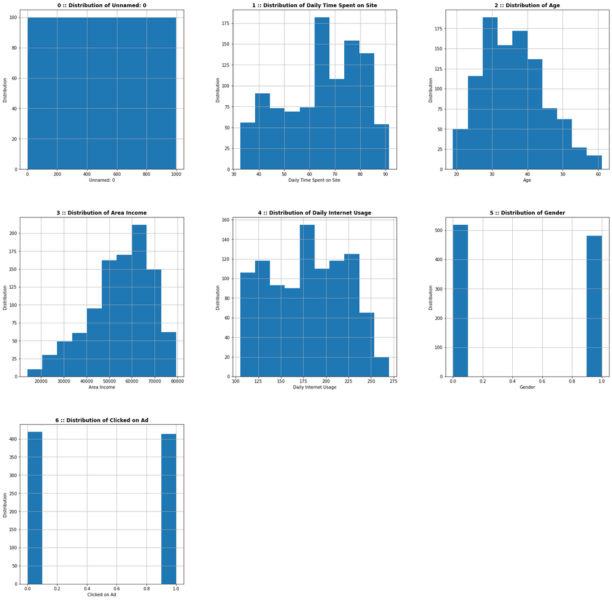

```python
hists = outDataFrame.hist(figsize=(25,25))
i = -1
for ax in hists.flatten():
    i += 1
    title = ax.get_title()
    ax.set_title(str(i)+" :: Distribution of %s" %title,fontweight = "bold")
    ax.set_xlabel(title)
    ax.set_ylabel("Distribution")
```

[output not shown]

[output not shown]

```
-نمودار 3 توزیع ویژگی "درآمد منطقه" است که نشان میدهد کاربران از سطوح مالی متفاوتند ولی با افزایش درآمد منطقه تا حد مشخصی، تعداد کاربران هم افزایش می یابد اما از بعد از 67000 تا 80000 با افزایش درآمد تعداد کاربران کاهش می یابد.
```

```
-نمودار 4 توزیع ویژگی "مصرف روزانه اینترنت" است که نشان میدهد اکثر کاربران سایت 170 تا 187 واحد زمان در اینترنت وقت می گذرانند. تنها 20 کاربر بیش از 252 واحد زمان در اینترنت وقت می گذرانند.
```

```
-نمودار 5 توزیع ویژگی "جنسیت" است که نشان میدهد توزیع زنان و مردان در 1000 کاربر به تقریب یکسان است ولی زنان کمی بیشترند که بالا تر هم با محاسبه تعداد زنان و مردان این مورد مشاهده شد.
```

```
-نمودار 6 توزیع ویژگی هدف یعنی "کلیک یا عدم کلیک روی تبلیغ" است که نشان میدهد اگر داده های خالی را در نظر نگیریم اکثر کاربران روی تبلیغ کلیک نکردند.
```

# ایجاد ابزار پیش بینی ویژگی هدف

## حذف مقادیر غیر عددی

```
در ادامه این پروژه ما میخواهیم در جهتی حرکت کنیم که با تقریب خوبی بتوانیم متغیر هدف را در جاهایی که خالی هستند پیش بینی کنیم. بدین جهت تنها از ویژگی های عددی استفاده میکنیم و بقیه را حذف میکنیم. ویژگی جنسیت را هم که ذاتاً غیر عددی بود و با برچسب گذاری به شکل عدد درآمد را هم حذف میکنیم. برای حذف از تابع ()drop کتابخانه pandas استفاده میکنیم و لیست ستون هایی که میخواهیم حذف شوند را به آن میدهیم و inplace را false میذاریم تا دیتافریم اولیه تغییر نکند.
```

```python
newDataFrame = outDataFrame.drop(["Ad Topic Line", "City", "Gender", "Country", "Timestamp"], axis = 1, inplace = False)
newDataFrame
```

|  | Unnamed: 0 | Daily Time Spent on Site | Age | Area Income | Daily Internet Usage | Clicked on Ad |
| --- | --- | --- | --- | --- | --- | --- |
| 0 | 0 | 68.950000 | 35.0 | 61833.90 | 256.090000 | 0.0 |
| 1 | 1 | 80.230000 | 31.0 | 68441.85 | 179.751271 | 0.0 |
| 2 | 2 | 69.470000 | 26.0 | 59785.94 | 236.500000 | 0.0 |
| 3 | 3 | 74.150000 | 29.0 | 54806.18 | 245.890000 | 0.0 |
| 4 | 4 | 68.370000 | 35.0 | 73889.99 | 225.580000 | 0.0 |
| ... | ... | ... | ... | ... | ... | ... |
| 995 | 995 | 72.970000 | 30.0 | 71384.57 | 208.580000 | 1.0 |
| 996 | 996 | 51.300000 | 45.0 | 67782.17 | 134.420000 | 1.0 |
| 997 | 997 | 51.630000 | 51.0 | 42415.72 | 120.370000 | 1.0 |
| 998 | 998 | 55.550000 | 19.0 | 41920.79 | 187.950000 | 0.0 |
| 999 | 999 | 64.794818 | 26.0 | 29875.80 | 178.350000 | 1.0 |

1000 rows × 6 columns

## نرمال سازی داده ها

```
همانطور که گفته شد در ادامه میخواهیم با کمک داده های عددی، هدف را در جاهایی که خالی است پیش بینی کنیم. اگر دقت کنیم میبینیم مقادیر نسبت داده شده به ویژگی های داده شده در یک اسکیل نیستند، مثلاً درآمد هر منطقه از 15000 تا 80000 متغیر است اما سن تنها از 18 تا 63 است. این مسئله کار ما را در آینده از نظر مقایسه و انتخاب بهترین و وابسته ترین ویژگی سخت میکند. بنابراین نیاز است داده ها را نرمال کنیم که همگی به تقریب در یک بازه قرار بگیرد. نرمال سازی راههای متفاوتی دارد اینجا با کم کردن میانگین(محاسبه شده با دستور()mean) از مقادیر و تقسیم کردن بر انحراف معیار(محاسبه شده با دستور()std) داده ها را نرمال میکنیم.
```

```python
features = ["Daily Time Spent on Site", "Age", "Area Income", "Daily Internet Usage"]
for feature in features:
    mean = newDataFrame[feature].mean()
    std = newDataFrame[feature].std(axis = 0, skipna = True)
    print(feature, "Mean::",mean, "SD::",std)
    newDataFrame[feature] = (newDataFrame[feature] - mean) / std
    newDataFrame[feature]
    print(feature, "Min::",newDataFrame[feature].min(), "Max::",newDataFrame[feature].max())
newDataFrame
```

```
Daily Time Spent on Site Mean:: 64.79481808158765 SD:: 15.194059737156483
Daily Time Spent on Site Min:: -2.11890822061575 Max:: 1.7529996840329023
Age Mean:: 36.00919305413687 SD:: 8.690825490724285
Age Min:: -1.9571435500909298 Max:: 2.8755389200411177
Area Income Mean:: 55000.000080000005 SD:: 13414.634022282358
Area Income Min:: -3.056624579685976 Max:: 1.8252305563707185
Daily Internet Usage Mean:: 179.75127053669223 SD:: 42.00025733423927
Daily Internet Usage Min:: -1.7850193140501183 Max:: 2.147813732316544
```

|  | Unnamed: 0 | Daily Time Spent on Site | Age | Area Income | Daily Internet Usage | Clicked on Ad |
| --- | --- | --- | --- | --- | --- | --- |
| 0 | 0 | 0.273474 | -0.116122 | 0.509436 | 1.817578 | 0.0 |
| 1 | 1 | 1.015870 | -0.576377 | 1.002029 | 0.000000 | 0.0 |
| 2 | 2 | 0.307698 | -1.151696 | 0.356770 | 1.351152 | 0.0 |
| 3 | 3 | 0.615713 | -0.806505 | -0.014448 | 1.574722 | 0.0 |
| 4 | 4 | 0.235301 | -0.116122 | 1.408163 | 1.091154 | 0.0 |
| ... | ... | ... | ... | ... | ... | ... |
| 995 | 995 | 0.538051 | -0.691441 | 1.221395 | 0.686394 | 1.0 |
| 996 | 996 | -0.888164 | 1.034517 | 0.952853 | -1.079309 | 1.0 |
| 997 | 997 | -0.866445 | 1.724900 | -0.938101 | -1.413831 | 1.0 |
| 998 | 998 | -0.608450 | -1.957144 | -0.974996 | 0.195207 | 0.0 |
| 999 | 999 | 0.000000 | -1.151696 | -1.872895 | -0.033363 | 1.0 |

1000 rows × 6 columns

[output not shown]

## جداسازی داده ها براساس هدف و محاسبه میانگین و انحراف معیار

```
در این قسمت برای راحتی مقایسه ویژگی ها در آینده و مقایسه رفتار آنها دو دیتافریم جدید ساختیم؛ یکی مخصوص ویژگی افرادی که روی آگهی کلیک کرده اند(clickedDataFrame) و دیگری مخصوص ویژگی افرادی که روی آگهی کلیک نکرده اند(notClickedDataFrame). همچنین به جهت شناخت بهتر این ویژگی ها برای هر دسته جداگانه میانگین و انحراف معیار را توسط توابع معرفی شده در مرحله قبل محاسبه می کنیم.
```

```python
clickedDataFrame = newDataFrame[newDataFrame["Clicked on Ad"] == 1.0]
clickedDataFrame
```

|  | Unnamed: 0 | Daily Time Spent on Site | Age | Area Income | Daily Internet Usage | Clicked on Ad |
| --- | --- | --- | --- | --- | --- | --- |
| 7 | 7 | 0.079319 | 1.379709 | -2.266679 | -1.142642 | 1.0 |
| 12 | 12 | 0.000000 | 1.379709 | -0.250702 | -1.586449 | 1.0 |
| 16 | 16 | -0.618980 | 0.114006 | -2.315616 | -1.198594 | 1.0 |
| 18 | 18 | -0.664392 | -0.001058 | -1.782565 | -1.460974 | 1.0 |
| 19 | 19 | 0.644014 | 0.459198 | -2.324199 | -1.053357 | 1.0 |
| ... | ... | ... | ... | ... | ... | ... |
| 994 | 994 | -1.388360 | -0.921569 | 0.605828 | -0.160505 | 1.0 |
| 995 | 995 | 0.538051 | -0.691441 | 1.221395 | 0.686394 | 1.0 |
| 996 | 996 | -0.888164 | 1.034517 | 0.952853 | -1.079309 | 1.0 |
| 997 | 997 | -0.866445 | 1.724900 | -0.938101 | -1.413831 | 1.0 |
| 999 | 999 | 0.000000 | -1.151696 | -1.872895 | -0.033363 | 1.0 |

413 rows × 6 columns

```python
notClickedDataFrame = newDataFrame[newDataFrame["Clicked on Ad"] == 0.0]
notClickedDataFrame
```

|  | Unnamed: 0 | Daily Time Spent on Site | Age | Area Income | Daily Internet Usage | Clicked on Ad |
| --- | --- | --- | --- | --- | --- | --- |
| 0 | 0 | 0.273474 | -0.116122 | 0.509436 | 1.817578 | 0.0 |
| 1 | 1 | 1.015870 | -0.576377 | 1.002029 | 0.000000 | 0.0 |
| 2 | 2 | 0.307698 | -1.151696 | 0.356770 | 1.351152 | 0.0 |
| 3 | 3 | 0.615713 | -0.806505 | -0.014448 | 1.574722 | 0.0 |
| 4 | 4 | 0.235301 | -0.116122 | 1.408163 | 1.091154 | 0.0 |
| ... | ... | ... | ... | ... | ... | ... |
| 986 | 986 | 0.000000 | -0.921569 | 0.370281 | 1.260200 | 0.0 |
| 988 | 988 | 1.639798 | 1.379709 | -0.260806 | 0.586871 | 0.0 |
| 989 | 989 | 0.405763 | -0.576377 | 0.014003 | 1.824959 | 0.0 |
| 993 | 993 | -0.039148 | -1.036633 | 0.834981 | 1.139963 | 0.0 |
| 998 | 998 | -0.608450 | -1.957144 | -0.974996 | 0.195207 | 0.0 |

419 rows × 6 columns

```python
features = ["Daily Time Spent on Site", "Age", "Area Income", "Daily Internet Usage"]
featureInfo = {}
for feature in features:
    clickedMean = clickedDataFrame[feature].mean()
    clickedSd = clickedDataFrame[feature].std(axis = 0, skipna = True)
    notClickedMean = notClickedDataFrame[feature].mean()
    notClickedSd = notClickedDataFrame[feature].std(axis = 0, skipna = True)
    featureInfo[feature] = [[clickedMean, clickedSd], [notClickedMean, notClickedSd]]
    print("Mean of %s and CLICKED is::" % feature ,clickedMean)
    print("SD of %s and CLICKED is::" % feature ,clickedSd)
    print("Mean of %s and NOT CLICKED is::" % feature , notClickedMean)
    print("SD of %s and NOT CLICKED is::" % feature , notClickedSd)
    print("-------------------------------------------\n")
```

```
Mean of Daily Time Spent on Site and CLICKED is:: -0.6917831722972694
SD of Daily Time Spent on Site and CLICKED is:: 0.8361610114854059
Mean of Daily Time Spent on Site and NOT CLICKED is:: 0.7141040932229988
SD of Daily Time Spent on Site and NOT CLICKED is:: 0.5313689387678912
-------------------------------------------

Mean of Age and CLICKED is:: 0.4932105470389866
SD of Age and CLICKED is:: 1.019267520705244
Mean of Age and NOT CLICKED is:: -0.49314845603668833
SD of Age and NOT CLICKED is:: 0.7063146454191541
-------------------------------------------

Mean of Area Income and CLICKED is:: -0.4986318539824453
SD of Area Income and CLICKED is:: 1.0461990555400822
Mean of Area Income and NOT CLICKED is:: 0.4763668327659723
SD of Area Income and NOT CLICKED is:: 0.6704761762169467
-------------------------------------------

Mean of Daily Internet Usage and CLICKED is:: -0.7533953136510781
SD of Daily Internet Usage and CLICKED is:: 0.7239588576012945
Mean of Daily Internet Usage and NOT CLICKED is:: 0.7642163719611866
SD of Daily Internet Usage and NOT CLICKED is:: 0.592057888773502
-------------------------------------------
```

```
-همانطور که در بالا میبینیم میانگین و انحراف معیار هر داده ای در هر دو حالت کلیک کردن یا نکردن محاسبه شده است. برای آنکه در آینده به این اطلاعات نیاز خواهیم داشت این اطلاعات برای هر ویژگی در یک دیکشنری با کلید نام ویژگی ذخیره شده است.
```

## نمایش نمودار تابع چگالی احتمال (PDF) هر ویژگی

```
در این قسمت برای هر حالت کلیک کردن و نکردن به ازای هر ویژگی تابع چگالی آن را رسم کردیم. چگالی احتمال به کمک تابع norm.pdf که متعلق به کتابخانه scipy.stats است به راحتی محاسبه میشود. این تابع سه ورودی میگیرد: 1- متغیر 2- میانگین متغیر 3- انحراف از معیار متغیر. میانگین و انحراف معیار را از دیکشنری حاصل مرحله قبل استخراج کردیم. همچنین برای مقایسه راحت تر برای هر ویژگی هر دو حالت کلیک و عدم کلیک در یک نمودار و هم با نقطه و هم خط رسم شده. در ادامه این نمودارها را میبینید.
```

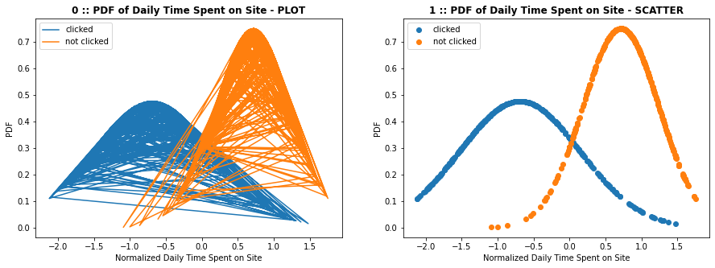

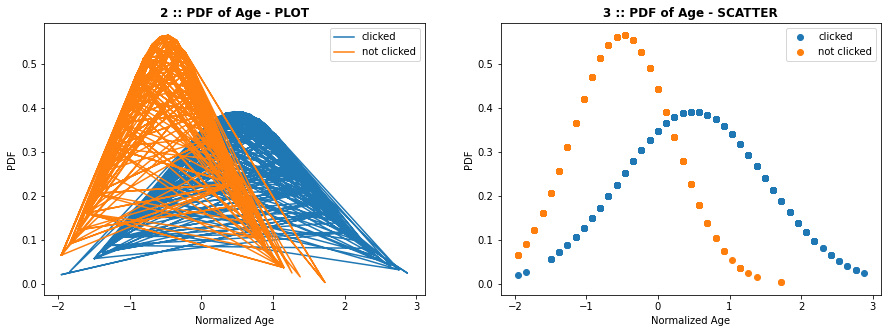

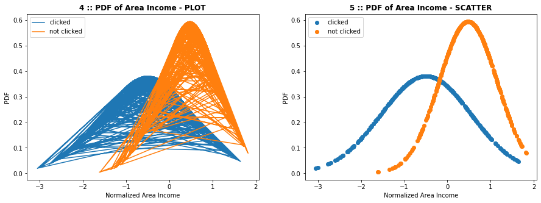

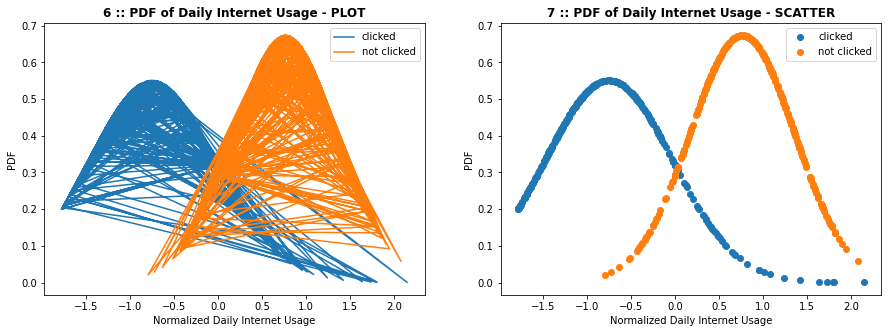

```python
features = ["Daily Time Spent on Site", "Age", "Area Income", "Daily Internet Usage"]
i = -1
for feature in features:
    i += 1
    x1 = clickedDataFrame[feature]
    y1 = norm.pdf(x1, featureInfo[feature][0][0], featureInfo[feature][0][1])
    x2 = notClickedDataFrame[feature]
    y2 = norm.pdf(x2, featureInfo[feature][1][0], featureInfo[feature][1][1])
    mplot.figure(figsize=(15,5))
    mplot.subplot(1, 2, 1)
    mplot.plot(x1, y1)
    mplot.plot(x2, y2)
    mplot.legend(["clicked","not clicked"])
    mplot.title(str(i)+" :: PDF of %s - PLOT" % feature,fontweight = "bold")
    mplot.xlabel("Normalized %s" % feature)
    mplot.ylabel("PDF")
    i += 1
    mplot.subplot(1, 2, 2)
    mplot.scatter(x1, y1)
    mplot.scatter(x2, y2)
    mplot.legend(["clicked","not clicked"])
    mplot.title(str(i)+" :: PDF of %s - SCATTER" % feature,fontweight = "bold")
    mplot.xlabel("Normalized %s" % feature)
    mplot.ylabel("PDF")
    mplot.show()
```

```
- برای تحلیل نمودارهای حاصل ابتدا بهتر است مفهوم تابع چگالی احتمال را مرور کنیم. تابع چگالی احتمال یعنی برای هر متغیری به اندازه ی مساحت زیر نمودار آن ناحیه، احتمال دارد متغیر در آن ناحیه قرار بگیرد. با توجه به این تعریف ما دنبال ویژگی هستیم که راحت بتوان برای دو حالت نمودار ها و در اصل احتمال رخ دادن را تمییز داد. یعنی به دنبال نمودارهایی هستیم که کمترین میزان اشتراک در دو حالت را داشته باشند و بتوانیم بگوییم از جایی به بعد به احتمال بیشتر کاربر کلیک کرده یا نکرده.
 نمودار 0 و 1: این دو نمودار چگالی احتمال کلیک و عدم کلیک ویژگی زمان سپری شده در سایت است.
 نمودار 2 و 3: این دو نمودار چگالی احتمال کلیک و عدم کلیک ویژگی سن است.
 نمودار 4 و 5: این دو نمودار چگالی احتمال کلیک و عدم کلیک ویژگی درآمد منطقه است.
 نمودار 6 و 7: این دو نمودار چگالی احتمال کلیک و عدم کلیک ویژگی مصرف روزانه اینترنت است.
 در نمودار های سن و درآمد منطقه مقدار اشتراک چشم گیر و زیادی به چشم میخورد و حذف میشوند ولی برای مصرف روزانه اینترنت و زمان سپری شده در سایت به مقایسه دقیق تری نیاز داریم.
```

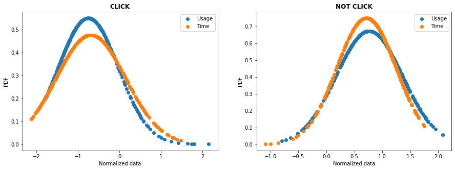

```python
x = clickedDataFrame["Daily Internet Usage"]
x1 = clickedDataFrame["Daily Time Spent on Site"]
x2 = notClickedDataFrame["Daily Internet Usage"]
x3 = notClickedDataFrame["Daily Time Spent on Site"]
clickUsage =norm.pdf(clickedDataFrame["Daily Internet Usage"], featureInfo["Daily Internet Usage"][0][0], featureInfo["Daily Internet Usage"][0][1])
noClickUsage = norm.pdf(notClickedDataFrame["Daily Internet Usage"], featureInfo["Daily Internet Usage"][1][0], featureInfo["Daily Internet Usage"][1][1])
clickTime = norm.pdf(clickedDataFrame["Daily Time Spent on Site"], featureInfo["Daily Time Spent on Site"][0][0], featureInfo["Daily Time Spent on Site"][0][1])
noClickTime =norm.pdf(notClickedDataFrame["Daily Time Spent on Site"], featureInfo["Daily Time Spent on Site"][1][0], featureInfo["Daily Time Spent on Site"][1][1])
mplot.figure(figsize=(15,5))
mplot.subplot(1, 2, 1)
mplot.scatter(x, clickUsage)
mplot.scatter(x1, clickTime)
mplot.legend(["Usage","Time"])
mplot.title("CLICK",fontweight = "bold")
mplot.xlabel("Normalized data")
mplot.ylabel("PDF")
mplot.subplot(1, 2, 2)
mplot.scatter(x2, noClickUsage)
mplot.scatter(x3, noClickTime)
mplot.legend(["Usage","Time"])
mplot.title("NOT CLICK",fontweight = "bold")
mplot.xlabel("Normalized data")
mplot.ylabel("PDF")
mplot.show()
```

- برای مقایسه بهتر کلیک و عدم کلیک دو ویژگی را جدا کردیم و کلیک برای دو ویژگی را باهم و عدم کلیک آن دو را هم با هم میکشیم. در هردو عدم کلیک با کلیک از سمت چپشان تداخل دارد که میبینیم باهم یکسانند اما کلیک ها که با عدم کلیک از سمت راست تداخل دارند تفاوت کوچکی دارند که نشان میدهد ناحیه اشتراک **میزان استفاده روزانه کاربر از معیار مناسبی برای پیش بینی ویژگی هدف است.**

## پیش بینی

```
-برای پیش بینی باید نقطه تلاقی دو حالت کلیک و عدم کلیک نمودار میزان استفاده روزانه کاربر را بیابیم . سپس با توجه مقدار نرمال ویژگی میزان استفاده روزانه کاربر و جایگاه آن نسبت به نقطه تلاقی تصمیم میگیریم هدف چه باشد.
در اینجا برای نقطه تلاقی از حدس استفاده شده و برای هر حدس در ناحیه مثبت و منفی شکل رسم شده. سپس با زوم در تصویر و بررسی دیتافریم در ناحیه ها سعی شده دقیق ترین مقدار پیدا شود.
```

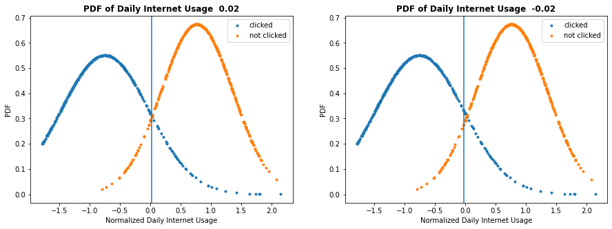

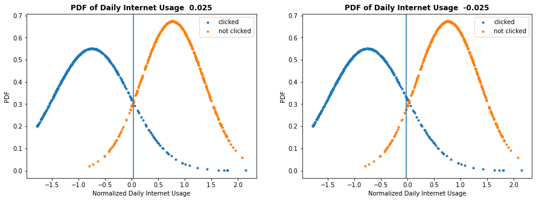

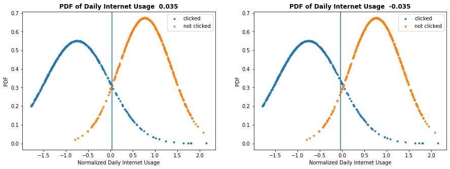

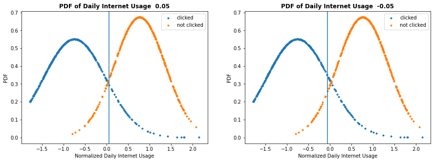

```python
feature = "Daily Internet Usage"
num = [0.02, 0.025, 0.035, 0.05]
for i in num:
    x1 = clickedDataFrame[feature]
    y1 = norm.pdf(x1, featureInfo[feature][0][0], featureInfo[feature][0][1])
    x2 = notClickedDataFrame[feature]
    y2 = norm.pdf(x2, featureInfo[feature][1][0], featureInfo[feature][1][1])
    mplot.figure(figsize=(15,5))
    mplot.subplot(1, 2, 1)
    mplot.plot(x1, y1,'.')
    mplot.plot(x2, y2,'.')
    mplot.axvline(x=i)
    mplot.legend(["clicked","not clicked"])
    mplot.title("PDF of %s  " % feature + str(i),fontweight = "bold")
    mplot.xlabel("Normalized %s" % feature)
    mplot.ylabel("PDF")
    mplot.subplot(1, 2, 2)
    mplot.plot(x1, y1, '.')
    mplot.plot(x2, y2, '.')
    mplot.axvline(x=-i)
    mplot.legend(["clicked","not clicked"])
    mplot.title("PDF of %s  " % feature + str(-i),fontweight = "bold")
    mplot.xlabel("Normalized %s" % feature)
    mplot.ylabel("PDF")
```

```python
con1 = newDataFrame["Daily Internet Usage"] > 0.035
# con2 = newDataFrame["Daily Internet Usage"] < 0.06
aData = newDataFrame[con1]
aData
print(sum(aData["Clicked on Ad"]==1.0))
```

```
41
```

- با توجه به نمودارای بالا و زوم روی آنها نقطه 0.035 انتخاب شد. البته یک تست دیگه هم انجام شد. در دیتافریم چک شد که برای داده نرمال بزرگتر از 0.035 در بین بیش از 400 نمونه تنها 41 داده کلیک کرده بودند و در نقاط دیگر چک شده این عدد بزرگتر میبود بنابراین این نقطه انتخاب شد.

## پر کردن خانه های خالی هدف

```
- بدین جهت ابتدا از روی دیتافریم با داده های نرمال یک دیتافریم جدید که مخصوص خانه های خالی ستون هدف بود ساختم. سپس در این دیتافریم داده هایی که مقدار ویژگی مصرف روزانه اینترنتشان کمتر از نقطه تلاقی بود را به عنوان داده های کلیک کرده در یک دیتافریم جدید ریختم و با ترکیب اندیس دیتافریم خالی و دیتافریم کلیک ها (دستور concat) یک دیتافریم ساختم که در این خانه هایی که درهدف خالی موندند خانه های عدم کلیک هستند. سپس با دستور to_csv دیتافریم نهایی را در یک فایل csv با نام out.csv ذخیره کردم.
```

```python
NanData = newDataFrame[outDataFrame["Clicked on Ad"].isna()]
surelyClicked = NanData[NanData["Daily Internet Usage"] < 0.035]
surelyClicked = surelyClicked["Clicked on Ad"].fillna(1.0)
result = panda.DataFrame(panda.concat([NanData["Unnamed: 0"],surelyClicked],axis=1))
result["Clicked on Ad"].fillna(0.0, inplace = True)
result
```

|  | Unnamed: 0 | Clicked on Ad |
| --- | --- | --- |
| 10 | 10 | 1.0 |
| 14 | 14 | 1.0 |
| 15 | 15 | 1.0 |
| 20 | 20 | 0.0 |
| 24 | 24 | 1.0 |
| ... | ... | ... |
| 963 | 963 | 0.0 |
| 966 | 966 | 1.0 |
| 967 | 967 | 0.0 |
| 977 | 977 | 1.0 |
| 992 | 992 | 1.0 |

168 rows × 2 columns

```python
result.to_csv("out.csv")
```

# نتیجه گیری

```
هنگامی که در مسائل هوش مصنوعی میخواهیم متغیر هدف را پیش بینی کنیم توجه به نرمال بودن داده ها و روش مناسب برای آنالیز کردن داده های گم شده بسیار حائز اهمیت است و انتخاب روش مناسب که باعث از دست رفتن داده ها نشود مهم است. همچنین حالات مختلف متغیر هدف برای هر ویژگی را کنار هم قرار دادن دید خوبی برای تصمیم گیری به ما میدهد. همچنین یکی از راههای تصمیم گیری توجه به تابع چگالی احتمال است.
```